# day5_homework

通过input输入一个字符，并判断它的类型，然后输出它是什么类型。 可以无限次输入，直至自己输入‘退出’才会结束。 例如： [1,24] --->print('您输入的是列表') Csd --->print('您输入的是字符串')

```python
while 1:
    a=input()
    if a=='退出':
        break
    else:
        try:
            if type(eval(a))==list:
                print('您输入的是列表')
            elif type(eval(a))==int:
                print('您输入的是整数')
            elif type(eval(a))==float:
                print('您输入的是浮点数')
            elif type(eval(a))==set:
                print('您输入的是集合')
            elif type(eval(a))==dict:
                print('您输入的是字典')
        except:
            print('您输入的是字符串')
```

```
1
您输入的是整数
1.0
您输入的是浮点数
{}
您输入的是字典
[]
您输入的是列表
a
s
d
您输入的是字符串
退出
```

将字符串 去重并从小到大排序输出， 排序可用sorted()。 例如 s = “ajldjlajfdljfddd”---->”adfjl”。

```python
s = 'ajldjlajfdljfddd'
def change(s):
    a=''
    for i in s:
        if i not in a:
            a=a+i
    a=sorted(a)
    b=''
    for i in a:
        b=b+i
    return b
s=change(s)
s
```

```
'adfjl'
```

根据num.txt，设计函数，计算每个小列表里面的平均人数。 例如：

['1000人以上'] ----> 1000 ['50-150人'] ----> （150+50）/2 = 100, [''] ----> 0 最终结果保存在列表中，例如：[['50-150人'], [''],['1000人以上'] ] --> [100,0,1000,...]

```python
with open('./data/num.txt') as f:
    num=f.readlines()
sp=num[0].replace("''","\'0\'").split("\'")
b=[]
for i in sp:
    if i=='10000人以上':
        x=1000
        b.append(x)
    elif i=='50-150人':
        x=(150+50)/2
        b.append(x)
    elif i=='10000以上':
        x=1000
        b.append(x)
    elif i=='150-500人':
        x=(150+500)/2
        b.append(x)
    elif i=='500-1000人':
        x=(500+1000)/2
        b.append(x)
    elif i=='5000-10000':
        x=(5000+10000)/2
        b.append(x)
    elif i=='500-1000':
        x=(500+1000)/2
        b.append(x)
    elif i=='150-500':
        x=(150+500)/2
        b.append(x)
    elif i== '1000-5000':
        x=(1000+5000)/2
        b.append(x)
    elif i=='1000-5000人':
        x=(1000+5000)/2
        b.append(x)
    elif i=='少于50人':
        x=50
        b.append(x)
    elif i=='5000-10000人':
        x=(5000+10000)/2
        b.append(x)
    elif i=='50-150':
        x=(150+50)/2
        b.append(x)
    elif i=='0':
        b.append(0)
b
```

```
[1000,
 100.0,
 1000,
 325.0,
 1000,
 750.0,
 1000,
 7500.0,
 750.0,
 325.0,
 3000.0,
 325.0,
 1000,
 1000,
 1000,
 3000.0,
 3000.0,
 1000,
 325.0,
 750.0,
 325.0,
 750.0,
 1000,
 100.0,
 100.0,
 100.0,
 100.0,
 750.0,
 325.0,
 3000.0,
 325.0,
 100.0,
 1000,
 0,
 100.0,
 325.0,
 750.0,
 100.0,
 750.0,
 3000.0,
```

[output cut: 946 more lines]

```
 50,
 0,
 50,
 325.0,
 100.0,
 100.0,
 50,
 3000.0,
 325.0,
 325.0,
 50,
 750.0,
 50,
 100.0,
 ...]
```

定义了一个 Car 类，它有 brand、model 和 year 属性，表示汽车的品牌、型号和制造年份。还有 speed 属性表示当前车速。 类中定义三个方法：accelerate（加速）、brake（刹车）和 get_speed（获取速度）。 accelerate可以输入加速参数increment表示加速了多少，输出经过加速后汽车的速度 brake可以输入参数decrement表示减速了多少，输出减速后的汽车速度 get_speed可以获取当前汽车的速度

```python
class Car:
    def __init__(self,brand,model,year,speed):
        self.brand=brand
        self.model=model
        self.year=year
        self.speed=speed

    def accelerate(self,increment):
        self.speed=self.speed+increment
        return print(f'加速后速度为{self.speed}')

    def brake(self,decrement):
        self.speed=self.speed-decrement
        if self.speed<=0:
            return print(f'减速后速度为0')
        else:
            return print(f'减速后速度为{self.speed}')
    def get_speed(self):
        if self.speed>0:
            return print(f'当前速度为{self.speed}')
        else:
            return print('当前速度为0')
```

```python
car=Car('法拉利','x80','2002-11-10',100)
car.get_speed()
car.accelerate(20)
car.brake(100)
car.brake(50)
car.get_speed()
```

```
当前速度为100
加速后速度为120
减速后速度为20
减速后速度为0
当前速度为0
```

内容判断

a = [1,2,3] 与 b = [3,2,1]，两个列表中的内容是一样的，怎么判断出来？

提示：集合

```python
a=[1,2,3]
b=[3,2,4]
x=0
if a==b:
    x=1
x
```

```
0
```

```python
a=set(a)
b=set(b)
if a==b:
    x=1
x
```

```
0
```

```python
a=[1,2,3]
b=[3,2,1]
x=0
if a==b:
    x=1
x
```

```
0
```

```python
a=set(a)
b=set(b)
if a==b:
    x=1
x
```

```
1
```

（os、shutil模块的内容） 创建一个函数copy_directory，传入两个参数source_dir、destination_dir分别表示源文件夹和目标文件夹。 该函数作用是判断目标文件夹是否存在，如果不存在则新建，如果存在则把源文件夹下所有的内容复制到目标文件夹里面。

```python
import os
import shutil

def copy_directory(source_dir,destination_dir):
    if os.path.exists(destination_dir):#如果目标目录已存在则执行
        for ipath in os.listdir(source_dir):#循环源文件夹下的文件
            filedir=os.path.join(source_dir,ipath)#将源文件夹下的文件名与源文件夹的路径拼接形成改文件的路径
            shutil.copy(filedir,destination_dir)#将改文件复制到目标文件夹
    else:#如果目标文件夹不存在则执行
        shutil.copytree(source_dir,destination_dir)#shutil.copytree会先创建改文件夹再将源文件夹下的文件复制到目标文件夹
```

```python
path1='./data/'
path2='./dir/'
copy_directory(path1,path2)
```

目标文件夹已存在

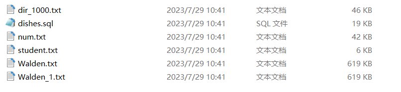

目标文件夹不存在

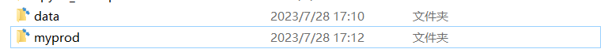

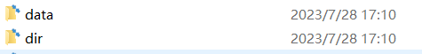

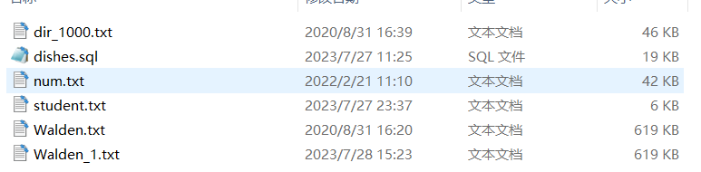

python程序设计思维，井字棋游戏：构建棋盘3X3的棋盘，X和O分别下棋，当三个棋连成线时胜出。已在board中给出棋盘的位置以及初始的字符串,并可以通过print_board()打印每次下棋后的棋盘结果。 思路： A. 11，12，32等表示棋盘的位置，通过input提示X和O输入下棋的位置 B. 对输入的位置判断是否合法，只能是11，12，13，21，22，23，31，32，33几个位置，并且位置被占用之后不能重新下棋，例如：位置11被X占用之后，O不能再占用11。 C.每走一步判断谁输谁赢（三个棋连成线则赢，思考该怎么完成这个判断过程？），直到一方胜出或者走完9步为止则游戏结束。